# Overview of the FFTrees Package

Nathaniel Phillips

2016-08-16

## Fast and Frugal Trees (FFTs)

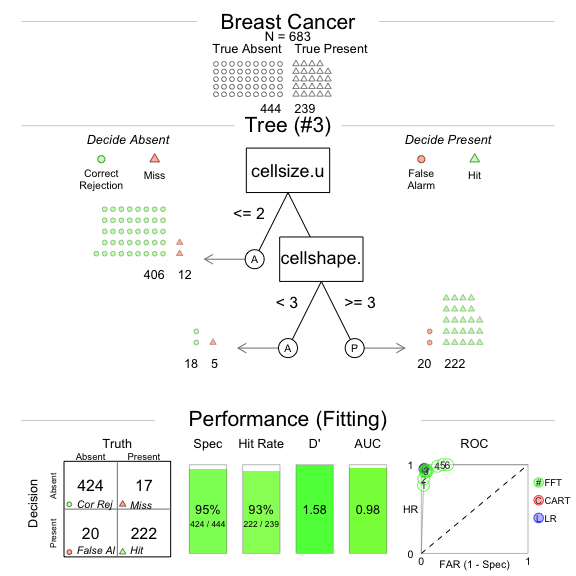

What is a Fast and Frugal Tree (FFT)? An FFT is a set of rules for making decisions based on very little information (usually 1 to 5 pieces). For example, the tree above uses data from breast cancer patients to decide whether a woman truly has breast cancer or not based on only two pieces of information.

FFTs are simple, transparent decision strategies that use minimal information to make decisions (see Gigerenzer & Todd, 1999; Gigerenzer, Czerlinski, & Martignon, 1999). They are frequently prefereable to more complex decision strategies (such as Logistic Regression) because they rarely overfit data (Gigerenzer & Brighton, 2009) and are easy to interpret and impliment in real-world decision tasks (Marewski & Gigerenzer, 2012). They have been used in real world tasks from detecting depression (Jenny, Pachur, Williams, Becker, & Margraf, 2013), to making fast decisions in emergency rooms (Green & Mehr, 1997).

The purpose of the `FFTrees` package is to produce, compare, and display (FFTs). The main function in the package is `fft()` which takes formula `formula` and dataset `data` arguments and returns several FFTs which attempt to classify training cases into criterion classes. For additional details and examples, check out the vignettes below:

## Vignettes

To learn more about the package, click the following vignettes:

- Creating FFTs with fft()
- Visualizing FFTs with plot()
- Lots of example FFTs

## Datasets

The package contains several datasets taken from the [UCI Machine Learning Repository](http://archive.ics.uci.edu/ml/) that you can use to play around with FFTs.

- `heartdisease` – patients suspected of having heart disease [source](http://archive.ics.uci.edu/ml/datasets/Heart+Disease)
- `breastcancer` – patients suspected of having breast cancer source
- `titanic` – records of which passengers on the Titanic survived
- `forestfires` – forest fire statistics [source](http://archive.ics.uci.edu/ml/datasets/Forest+Fires)
- `wine` – ratings of wine quality [source](http://archive.ics.uci.edu/ml/datasets/Wine)
- `income` – Census data from > 30,000 US residents [source](http://archive.ics.uci.edu/ml/datasets/Adult)
- `bank` – Bank marketing dataset [source](http://archive.ics.uci.edu/ml/datasets/Bank+Marketing)

## Contact

This package is constantly being updated. For comments, tips, additional references, and bug reports, please add an issue at https://github.com/ndphillips/FFTrees/issues or email me at Nathaniel.D.Phillips.is@gmail.com.

## Bibliography

Gigerenzer, G., & Brighton, H. (2009). Homo heuristicus: Why biased minds make better inferences. *Topics in Cognitive Science*, *1*(1), 107–143.

Gigerenzer, G., & Todd, P. M. (1999). Fast and frugal heuristics: The adaptive toolbox. In *Simple heuristics that make us smart* (pp. 3–34). Oxford University Press.

Gigerenzer, G., Czerlinski, J., & Martignon, L. (1999). How good are fast and frugal heuristics? In *Decision science and technology* (pp. 81–103). Springer.

Green, L., & Mehr, D. R. (1997). What alters physicians’ decisions to admit to the coronary care unit? *Journal of Family Practice*, *45*(3), 219–226.

Jenny, M. A., Pachur, T., Williams, S. L., Becker, E., & Margraf, J. (2013). Simple rules for detecting depression. *Journal of Applied Research in Memory and Cognition*, *2*(3), 149–157.

Marewski, J. N., & Gigerenzer, G. (2012). Heuristic decision making in medicine. *Dialogues Clin Neurosci*, *14*(1), 77–89.